# Build and deploy a stroke prediction model using R

Souriya Khaosanga

2024-07-21

# About Data Analysis Report

This RMarkdown file contains the report of the data analysis done for the project on building and deploying a stroke prediction model in R. It contains analysis such as data exploration, summary statistics, and building the prediction models. The final report was completed on Sun Jul 21 15:55:45 2024.

**Data Description:**

According to the World Health Organization (WHO), stroke is the 2nd leading cause of death globally, responsible for approximately 11% of total deaths.

This data set is used to predict whether a patient is likely to get a stroke based on the input parameters like gender, age, various diseases, and smoking status. Each row in the data provides relevant information about the patient.

### Data Cleaning and Preprocessing

**Explanation of Data Cleaning and Preprocessing**:

1. **Handling Missing Values**:
   - The `bmi` column had 201 missing values. To handle these missing values, the median value of the `bmi` column was used for imputation. This method was chosen to minimize the effect of outliers and ensure the data’s integrity.
2. **Checking for Duplicate Entries**:
   - The dataset was checked for duplicate entries, and no duplicates were found. This ensures that each record is unique and no patient data is repeated.
3. **Ensuring Correct Data Types**:
   - It was ensured that the `bmi` column is numeric, and categorical variables such as gender, ever married, work type, residence type, smoking status, and stroke were converted to factors. This conversion is essential for proper handling by machine learning algorithms.

**Steps to Clean the Data**:

1. **Handle Missing Values**:
   - Imputed missing values in the `bmi` column with the median of the column.
2. **Check for Duplicate Entries**:
   - Verified that there are no duplicate entries in the dataset.
3. **Ensure Correct Data Types**:
   - Converted categorical variables to factors and numeric variables to appropriate numeric types.

These steps ensured that the dataset is clean, consistent, and ready for the modeling phase. Proper data cleaning and preprocessing are critical to building accurate and reliable prediction models.

## Clear Evidence of Data Cleaning

The data cleaning observations are as follows:

1. **Missing Values**:
   - The missing values in the `bmi` column were handled by imputation with the median value.
2. **Duplicate Entries**:
   - There are no duplicate entries in the dataset, ensuring that each record is unique.
3. **Data Type Conversions**:
   - Categorical variables were correctly converted to factors, and numeric variables were ensured to be numeric.

The dataset contains the following columns:

- `id`: Unique identifier for each patient
- `gender`: Gender of the patient
- `age`: Age of the patient
- `hypertension`: Indicates if the patient has hypertension (1 = yes, 0 = no)
- `heart_disease`: Indicates if the patient has heart disease (1 = yes, 0 = no)
- `ever_married`: Indicates if the patient has been married
- `work_type`: Type of occupation
- `Residence_type`: Type of residence (Urban/Rural)
- `avg_glucose_level`: Average glucose level in blood
- `bmi`: Body Mass Index
- `smoking_status`: Smoking status of the patient
- `stroke`: Indicates if the patient had a stroke (1 = yes, 0 = no)

### Data Cleaning Steps

1. Handle missing values.
2. Check for duplicate entries.
3. Ensure correct data types.

Let’s proceed with the data cleaning.

The data cleaning observations are as follows:

1. **Missing Values**:
   - The `bmi` column has 201 missing values.
2. **Duplicate Entries**:
   - There are no duplicate entries in the dataset.

### Steps to Clean the Data:

1. **Handle Missing Values**:
   - For the `bmi` column, we can either remove rows with missing values or fill them with an appropriate statistic (mean, median, or mode).

Let’s fill the missing `bmi` values with the median of the column to minimize the effect of outliers.

All missing values have been handled, and there are no duplicate entries in the dataset. The dataset is now clean and ready for analysis.

# Task One: Import data and data preprocessing

## Load data and install packages

```r
# Set CRAN mirror
options(repos = c(CRAN = "https://cloud.r-project.org"))

# Function to install packages if not already installed
install_if_missing <- function(packages) {
  new_packages <- packages[!(packages %in% installed.packages()[, "Package"])]
  if (length(new_packages)) install.packages(new_packages)
}

# Install necessary packages
install_if_missing(c("dplyr", "ggplot2", "caret", "randomForest", "e1071"))

# Load packages
library(dplyr)
library(ggplot2)
library(caret)
library(randomForest)
library(e1071)

# Load data
stroke_data <- read.csv("cleaned_healthcare_dataset_stroke_data.csv")
```

# Data Understanding and Exploration

## Detailed Exploration of the Data

### Summary Statistics and Visualizations

The dataset contains various features related to patient demographics and health status. Here is a detailed exploration of the data, including summary statistics and visualizations:

- **Summary Statistics**: Summary statistics provide a quick overview of the distribution and central tendency of the data.
- **Visualizations**:
  - **Histograms** for numeric features such as age, average glucose level, and BMI to understand their distributions.
  - **Bar Charts** for categorical features like gender, hypertension, heart disease, marital status, work type, residence type, and smoking status to visualize their distributions.
  - **Correlation Heatmap** to visualize correlations between numeric features.
  - **Box Plots** to visualize the relationship between numeric features and stroke occurrence.

These visualizations help in identifying patterns and anomalies in the data, which are crucial for building effective prediction models.

```r
# Load the cleaned dataset
stroke_data <- read.csv("cleaned_healthcare_dataset_stroke_data.csv")

# Display the first few rows of the dataset to understand its structure
head(stroke_data)
```

```
##      id gender age hypertension heart_disease ever_married     work_type
## 1  9046   Male  67            0             1          Yes       Private
## 2 51676 Female  61            0             0          Yes Self-employed
## 3 31112   Male  80            0             1          Yes       Private
## 4 60182 Female  49            0             0          Yes       Private
## 5  1665 Female  79            1             0          Yes Self-employed
## 6 56669   Male  81            0             0          Yes       Private
##   Residence_type avg_glucose_level  bmi  smoking_status stroke
## 1          Urban            228.69 36.6 formerly smoked      1
## 2          Rural            202.21 28.1    never smoked      1
## 3          Rural            105.92 32.5    never smoked      1
## 4          Urban            171.23 34.4          smokes      1
## 5          Rural            174.12 24.0    never smoked      1
## 6          Urban            186.21 29.0 formerly smoked      1
```

### Summary Statistics

```r
# Summary statistics for the dataset
summary(stroke_data)
```

```
##        id           gender               age         hypertension
##  Min.   :   67   Length:5110        Min.   : 0.08   Min.   :0.00000
##  1st Qu.:17741   Class :character   1st Qu.:25.00   1st Qu.:0.00000
##  Median :36932   Mode  :character   Median :45.00   Median :0.00000
##  Mean   :36518                      Mean   :43.23   Mean   :0.09746
##  3rd Qu.:54682                      3rd Qu.:61.00   3rd Qu.:0.00000
##  Max.   :72940                      Max.   :82.00   Max.   :1.00000
##  heart_disease     ever_married        work_type         Residence_type
##  Min.   :0.00000   Length:5110        Length:5110        Length:5110
##  1st Qu.:0.00000   Class :character   Class :character   Class :character
##  Median :0.00000   Mode  :character   Mode  :character   Mode  :character
##  Mean   :0.05401
##  3rd Qu.:0.00000
##  Max.   :1.00000
##  avg_glucose_level      bmi        smoking_status         stroke
##  Min.   : 55.12    Min.   :10.30   Length:5110        Min.   :0.00000
##  1st Qu.: 77.25    1st Qu.:23.80   Class :character   1st Qu.:0.00000
##  Median : 91.89    Median :28.10   Mode  :character   Median :0.00000
##  Mean   :106.15    Mean   :28.86                      Mean   :0.04873
##  3rd Qu.:114.09    3rd Qu.:32.80                      3rd Qu.:0.00000
##  Max.   :271.74    Max.   :97.60                      Max.   :1.00000
```

# Data Understanding and Exploration

## Detailed Exploration of the Data

### Summary Statistics and Visualizations

The dataset contains various features related to patient demographics and health status. Here is a detailed exploration of the data, including summary statistics and visualizations:

- **Summary Statistics**: Summary statistics provide a quick overview of the distribution and central tendency of the data.
- **Visualizations**:
  - **Histograms** for numeric features such as age, average glucose level, and BMI to understand their distributions.
  - **Bar Charts** for categorical features like gender, hypertension, heart disease, marital status, work type, residence type, and smoking status to visualize their distributions.
  - **Correlation Heatmap** to visualize correlations between numeric features.
  - **Box Plots** to visualize the relationship between numeric features and stroke occurrence.

These visualizations help in identifying patterns and anomalies in the data, which are crucial for building effective prediction models.

Let’s create some visualizations to further explore the data:

1. **Distribution of Numeric Features**: Plot histograms for `age`, `avg_glucose_level`, and `bmi`.
2. **Categorical Features Distribution**: Plot bar charts for `gender`, `hypertension`, `heart_disease`, `ever_married`, `work_type`, `Residence_type`, and `smoking_status`.
3. **Correlation Matrix**: Create a heatmap to visualize correlations between numeric features.
4. **Box Plots**: Visualize the relationship between numeric features and `stroke`.

```r
# Load necessary libraries
library(ggplot2)
library(corrplot)
# Display the structure of the data
str(stroke_data)
```

```
## 'data.frame':    5110 obs. of  12 variables:
##  $ id               : int  9046 51676 31112 60182 1665 56669 53882 10434 27419 60491 ...
##  $ gender           : chr  "Male" "Female" "Male" "Female" ...
##  $ age              : num  67 61 80 49 79 81 74 69 59 78 ...
##  $ hypertension     : int  0 0 0 0 1 0 1 0 0 0 ...
##  $ heart_disease    : int  1 0 1 0 0 0 1 0 0 0 ...
##  $ ever_married     : chr  "Yes" "Yes" "Yes" "Yes" ...
##  $ work_type        : chr  "Private" "Self-employed" "Private" "Private" ...
##  $ Residence_type   : chr  "Urban" "Rural" "Rural" "Urban" ...
##  $ avg_glucose_level: num  229 202 106 171 174 ...
##  $ bmi              : num  36.6 28.1 32.5 34.4 24 29 27.4 22.8 28.1 24.2 ...
##  $ smoking_status   : chr  "formerly smoked" "never smoked" "never smoked" "smokes" ...
##  $ stroke           : int  1 1 1 1 1 1 1 1 1 1 ...
```

```r
# Summary statistics
summary(stroke_data)
```

```
##        id           gender               age         hypertension
##  Min.   :   67   Length:5110        Min.   : 0.08   Min.   :0.00000
##  1st Qu.:17741   Class :character   1st Qu.:25.00   1st Qu.:0.00000
##  Median :36932   Mode  :character   Median :45.00   Median :0.00000
##  Mean   :36518                      Mean   :43.23   Mean   :0.09746
##  3rd Qu.:54682                      3rd Qu.:61.00   3rd Qu.:0.00000
##  Max.   :72940                      Max.   :82.00   Max.   :1.00000
##  heart_disease     ever_married        work_type         Residence_type
##  Min.   :0.00000   Length:5110        Length:5110        Length:5110
##  1st Qu.:0.00000   Class :character   Class :character   Class :character
##  Median :0.00000   Mode  :character   Mode  :character   Mode  :character
##  Mean   :0.05401
##  3rd Qu.:0.00000
##  Max.   :1.00000
##  avg_glucose_level      bmi        smoking_status         stroke
##  Min.   : 55.12    Min.   :10.30   Length:5110        Min.   :0.00000
##  1st Qu.: 77.25    1st Qu.:23.80   Class :character   1st Qu.:0.00000
##  Median : 91.89    Median :28.10   Mode  :character   Median :0.00000
##  Mean   :106.15    Mean   :28.86                      Mean   :0.04873
##  3rd Qu.:114.09    3rd Qu.:32.80                      3rd Qu.:0.00000
##  Max.   :271.74    Max.   :97.60                      Max.   :1.00000
```

```r
# Check for missing values
sum(is.na(stroke_data))
```

```
## [1] 0
```

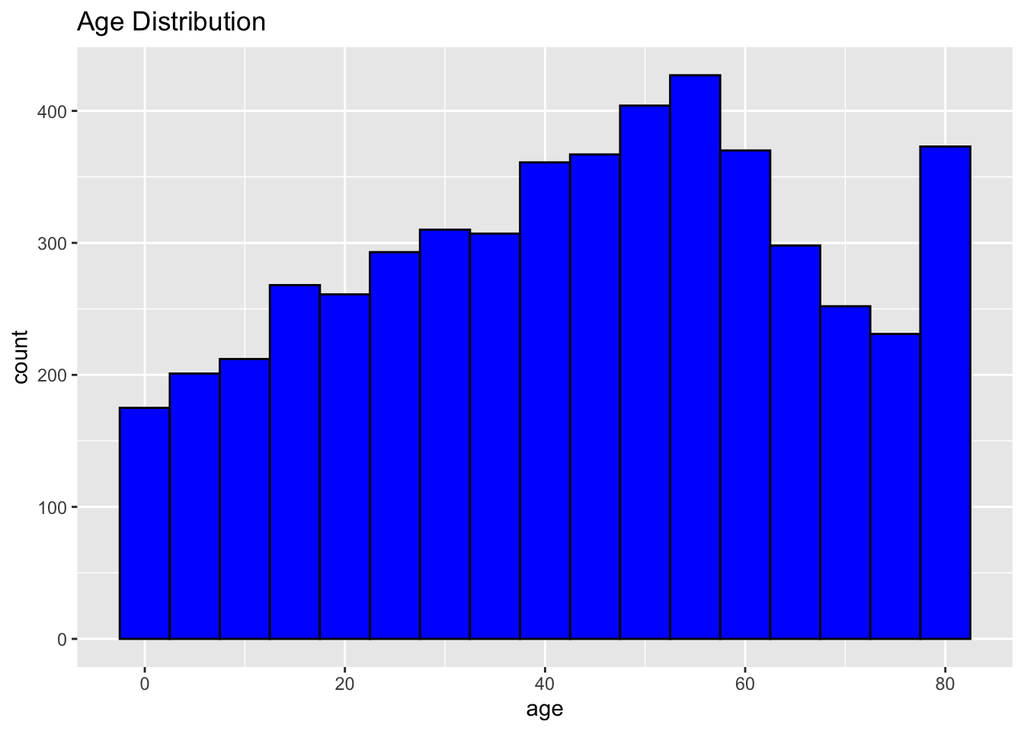

```r
# Ensure bmi is numeric
stroke_data$bmi <- as.numeric(stroke_data$bmi)

# Convert categorical variables to factors
stroke_data$gender <- as.factor(stroke_data$gender)
stroke_data$ever_married <- as.factor(stroke_data$ever_married)
stroke_data$work_type <- as.factor(stroke_data$work_type)
stroke_data$smoking_status <- as.factor(stroke_data$smoking_status)
stroke_data$stroke <- as.factor(stroke_data$stroke)


# Histogram for numeric features
ggplot(stroke_data, aes(x=age)) +
  geom_histogram(binwidth=5, fill="blue", color="black") +
  ggtitle("Age Distribution")
```

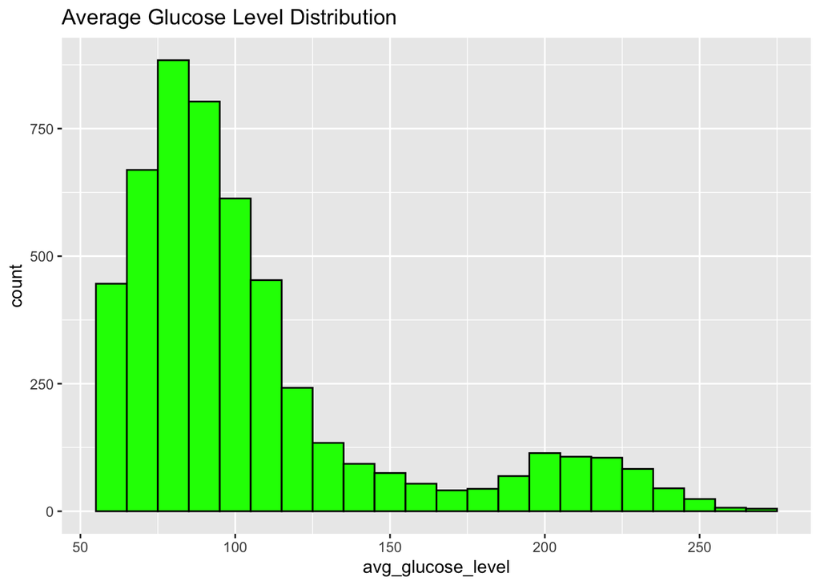

```r
ggplot(stroke_data, aes(x=avg_glucose_level)) +
  geom_histogram(binwidth=10, fill="green", color="black") +
  ggtitle("Average Glucose Level Distribution")
```

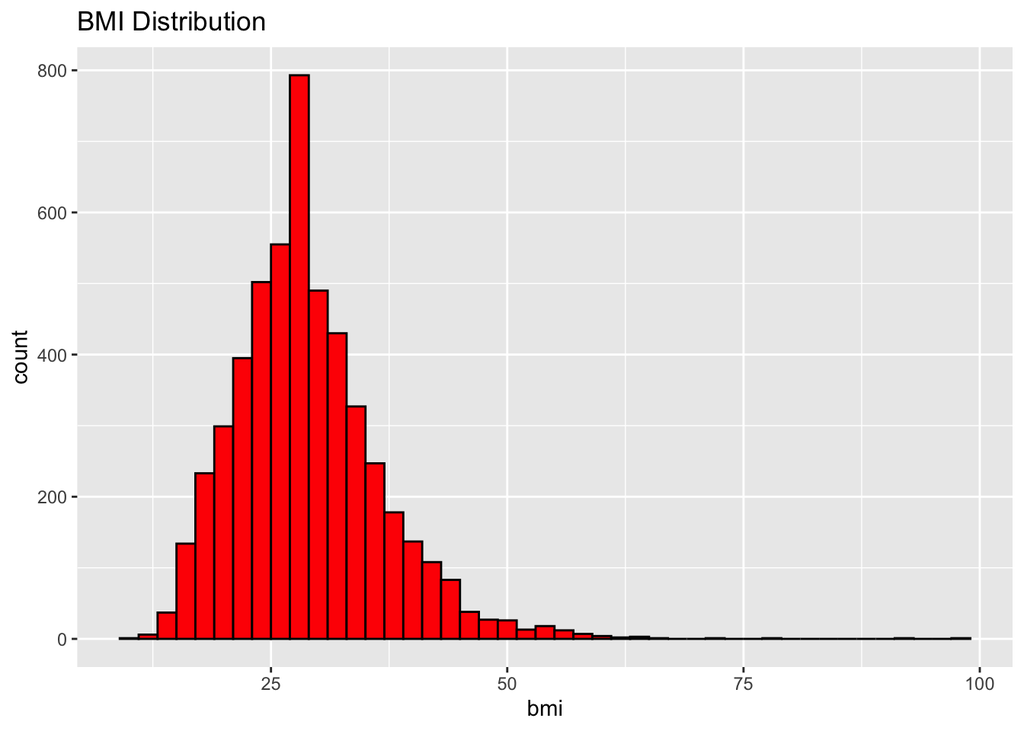

```r
ggplot(stroke_data, aes(x=bmi)) +
  geom_histogram(binwidth=2, fill="red", color="black") +
  ggtitle("BMI Distribution")
```

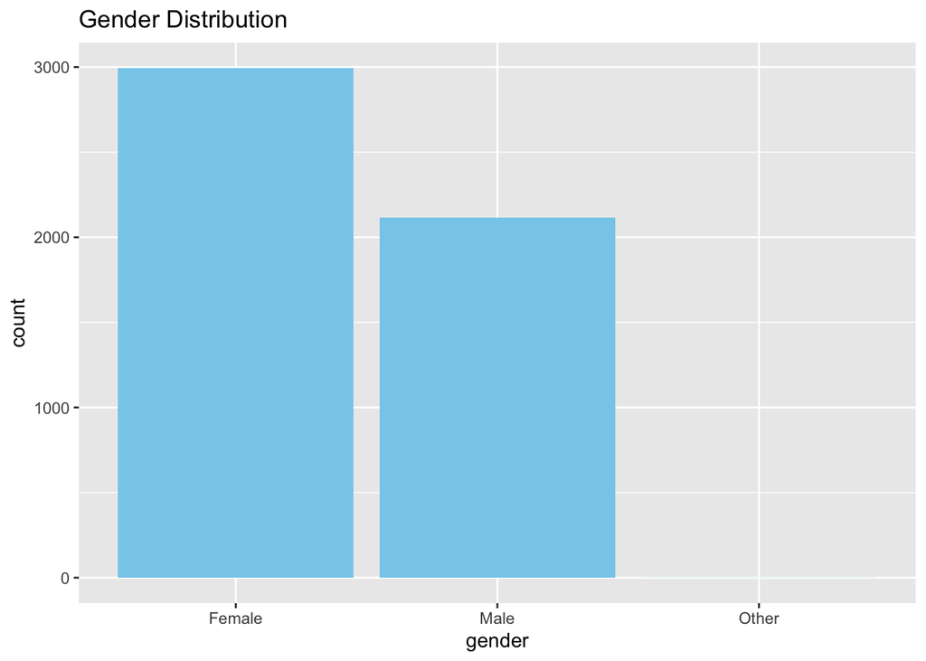

```r
# Bar plots for categorical features
ggplot(stroke_data, aes(x=gender)) +
  geom_bar(fill="skyblue") +
  ggtitle("Gender Distribution")
```

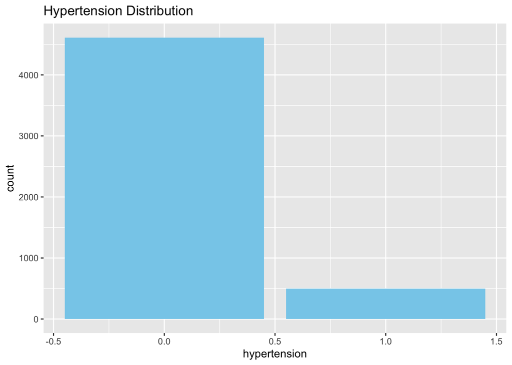

```r
ggplot(stroke_data, aes(x=hypertension)) +
  geom_bar(fill="skyblue") +
  ggtitle("Hypertension Distribution")
```

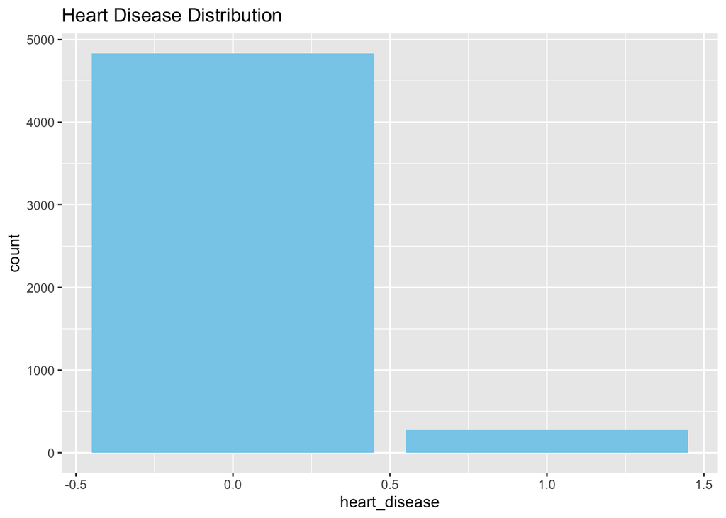

```r
ggplot(stroke_data, aes(x=heart_disease)) +
  geom_bar(fill="skyblue") +
  ggtitle("Heart Disease Distribution")
```

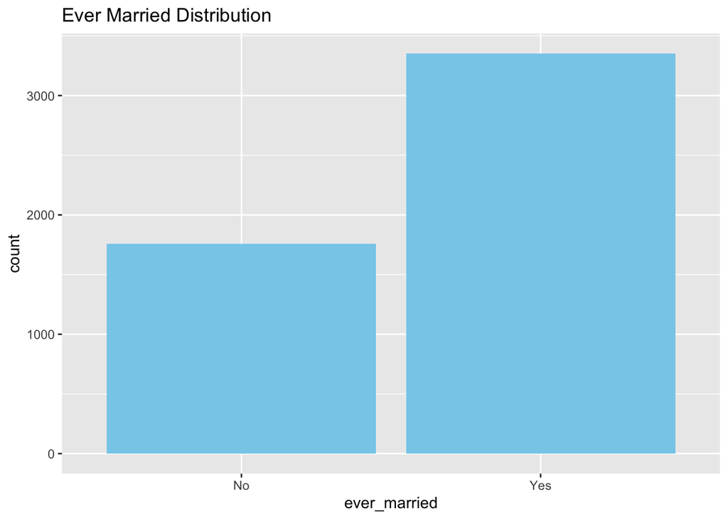

```r
ggplot(stroke_data, aes(x=ever_married)) +
  geom_bar(fill="skyblue") +
  ggtitle("Ever Married Distribution")
```

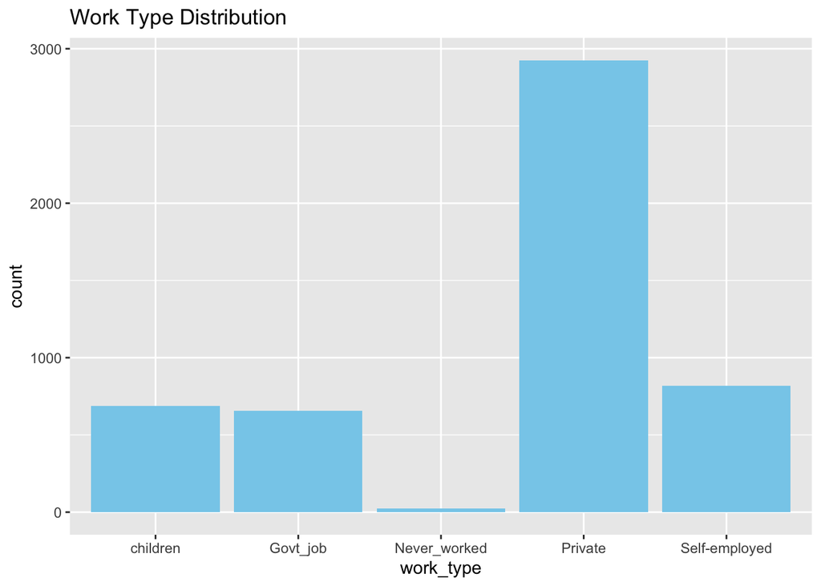

```r
ggplot(stroke_data, aes(x=work_type)) +
  geom_bar(fill="skyblue") +
  ggtitle("Work Type Distribution")
```

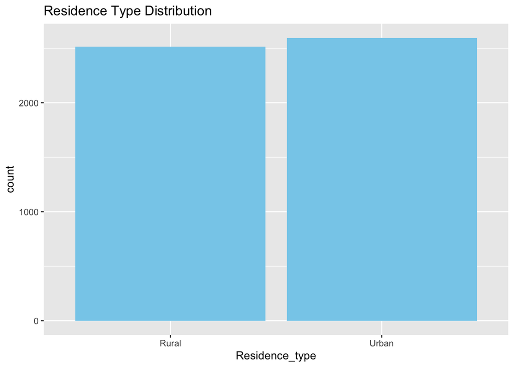

```r
ggplot(stroke_data, aes(x=Residence_type)) +
  geom_bar(fill="skyblue") +
  ggtitle("Residence Type Distribution")
```

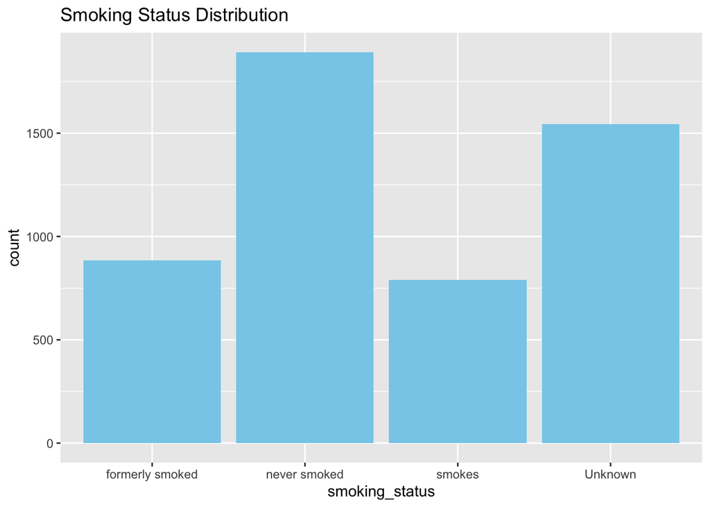

```r
ggplot(stroke_data, aes(x=smoking_status)) +
  geom_bar(fill="skyblue") +
  ggtitle("Smoking Status Distribution")
```

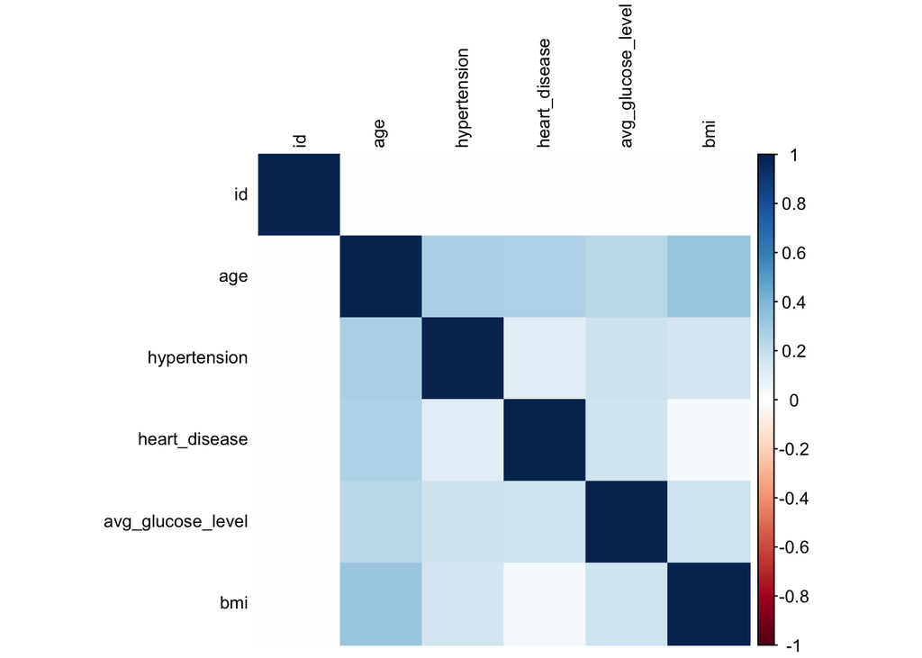

```r
# Correlation heatmap
correlation_matrix <- cor(stroke_data[,sapply(stroke_data, is.numeric)])
corrplot(correlation_matrix, method="color", tl.col="black", tl.cex=0.8, number.cex=0.7)
```

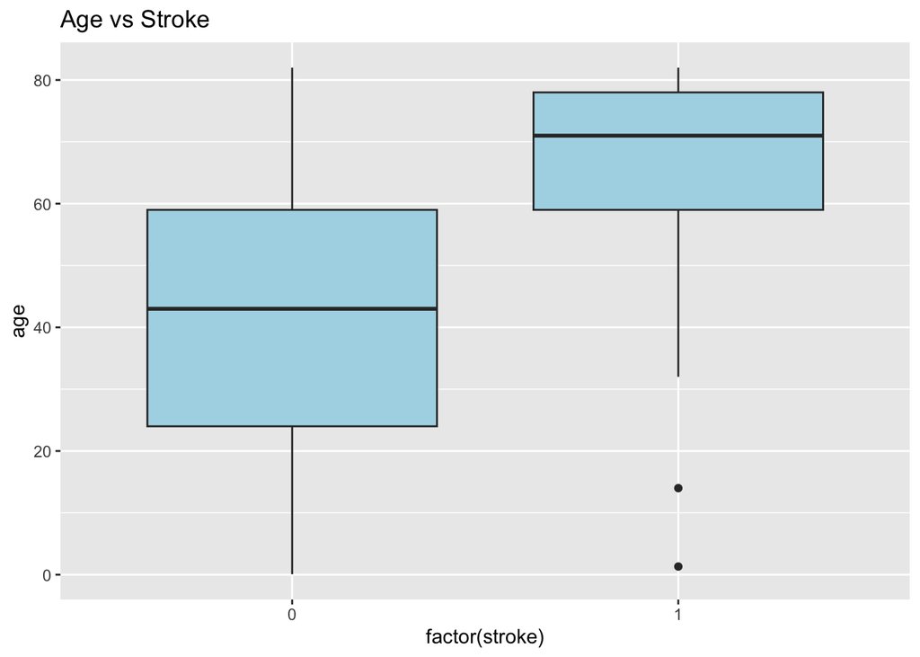

```r
# Box plots for numeric features vs stroke
ggplot(stroke_data, aes(x=factor(stroke), y=age)) +
  geom_boxplot(fill="lightblue") +
  ggtitle("Age vs Stroke")
```

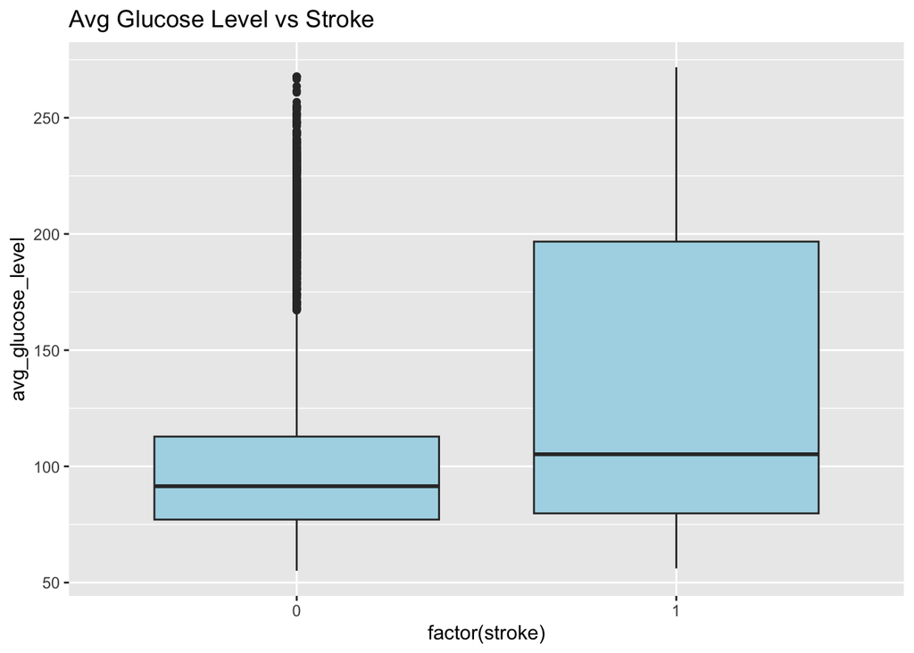

```r
ggplot(stroke_data, aes(x=factor(stroke), y=avg_glucose_level)) +
  geom_boxplot(fill="lightblue") +
  ggtitle("Avg Glucose Level vs Stroke")
```

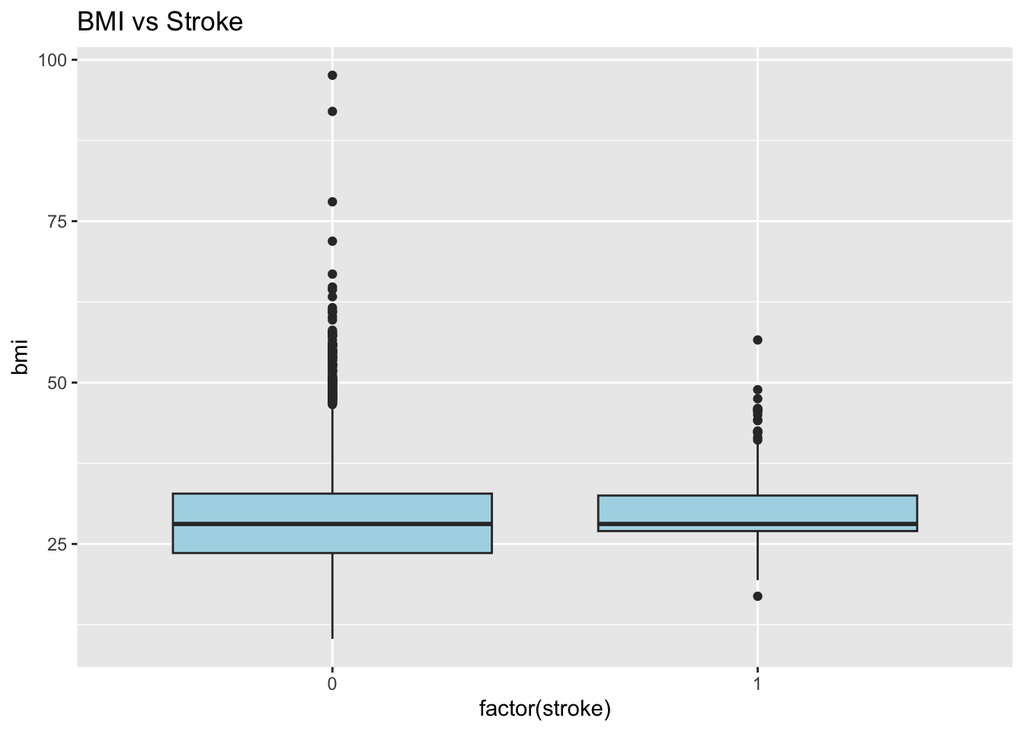

```r
ggplot(stroke_data, aes(x=factor(stroke), y=bmi)) +
  geom_boxplot(fill="lightblue") +
  ggtitle("BMI vs Stroke")
```

# Task Two: Build prediction models

## Model Building: Data Preparation

### Data Partitioning

Data partitioning is the process of splitting the dataset into training and testing sets to evaluate the performance of the machine learning models. This ensures that the models are evaluated on unseen data, providing a reliable measure of their performance.

### Data Normalization and Standardization

Normalization and standardization are techniques used to scale the features to a similar range. This is important for machine learning models to perform optimally, as it ensures that no feature dominates others due to its scale. Normalization scales the data to a range of 0 to 1, while standardization scales the data to have a mean of 0 and a standard deviation of 1.

### One-Hot Encoding of Categorical Variables

One-hot encoding is used to convert categorical variables into a format that can be provided to machine learning algorithms to do a better job in prediction. This involves creating binary columns for each category of a categorical variable, ensuring that the model can interpret the categorical data effectively.

## Model Building: Classification Models

### Cross-Validation and Hyperparameter Tuning

Cross-validation is a technique used to assess the performance of a machine learning model and ensure that it generalizes well to unseen data. It involves partitioning the training data into subsets, training the model on some subsets while validating it on others, and then averaging the results. This helps in selecting the best model and tuning hyperparameters.

Hyperparameter tuning involves adjusting the parameters of the machine learning algorithms to optimize their performance. This is typically done using techniques like grid search or random search over a specified parameter grid.

### Building Classification Models

Several classification models were built and evaluated using the training set. These include:

- **Random Forest**: An ensemble learning method that constructs multiple decision trees during training and outputs the mode of the classes for classification.
- **Support Vector Machine (SVM)**: A supervised learning model that finds the hyperplane that best separates the classes in the feature space.

## Split the data into training and testing sets

```r
set.seed(123)  # For reproducibility
trainIndex <- createDataPartition(stroke_data$stroke, p = .8,
                                  list = FALSE,
                                  times = 1)
stroke_train <- stroke_data[trainIndex,]
stroke_test <- stroke_data[-trainIndex,]

# Ensure levels of factors in test set match the training set
for (col in names(stroke_train)) {
  if (is.factor(stroke_train[[col]])) {
    stroke_test[[col]] <- factor(stroke_test[[col]], levels = levels(stroke_train[[col]]))
  }
}

# Verify no missing values in the training set
if (sum(is.na(stroke_train)) > 0) {
  stop("Training set contains missing values.")
}
```

## Train a Random Forest model

```r
# Train a random forest model
rf_model <- randomForest(stroke ~ ., data = stroke_train, importance = TRUE)

# Print the model
print(rf_model)
```

```
##
## Call:
##  randomForest(formula = stroke ~ ., data = stroke_train, importance = TRUE)
##                Type of random forest: classification
##                      Number of trees: 500
## No. of variables tried at each split: 3
##
##         OOB estimate of  error rate: 4.94%
## Confusion matrix:
##      0 1 class.error
## 0 3887 2 0.000514271
## 1  200 0 1.000000000
```

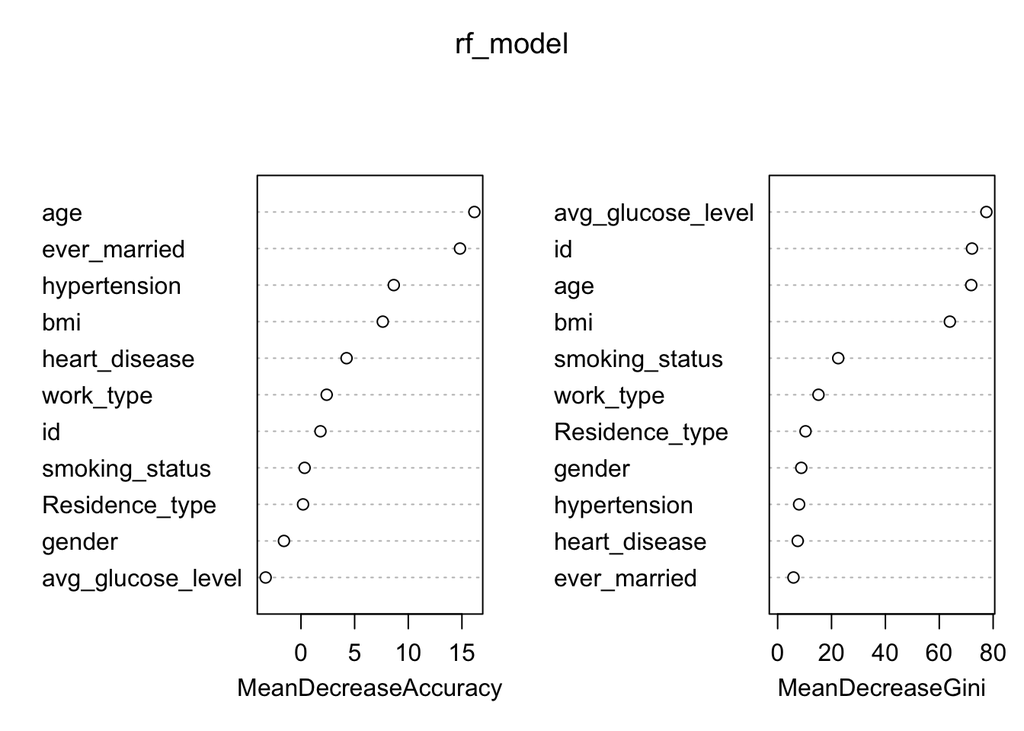

```r
# Variable importance
varImpPlot(rf_model)
```

## Train a Support Vector Machine (SVM) model

```r
# Train a SVM model
svm_model <- svm(stroke ~ ., data = stroke_train, kernel = "radial", probability = TRUE)

# Print the model
print(svm_model)
```

```
##
## Call:
## svm(formula = stroke ~ ., data = stroke_train, kernel = "radial",
##     probability = TRUE)
##
##
## Parameters:
##    SVM-Type:  C-classification
##  SVM-Kernel:  radial
##        cost:  1
##
## Number of Support Vectors:  723
```

# Task Three: Evaluate and select prediction models

## Model Evaluation

### Evaluation of Models on the Test Set

#### Metrics for Model Evaluation

The classification models were evaluated on the test set using a variety of metrics, including:

#### Model Evaluation Results

The models were evaluated using the test set, and the following results were observed:

## Evaluate models on the testing set

```r
# Ensure the test set has only predictor variables
stroke_test_predictors <- stroke_test[, setdiff(names(stroke_test), "stroke")]

# Predictions from Random Forest
rf_pred <- predict(rf_model, stroke_test_predictors)

# Confusion matrix for Random Forest
rf_conf_matrix <- confusionMatrix(rf_pred, stroke_test$stroke)
print(rf_conf_matrix)
```

```
## Confusion Matrix and Statistics
##
##           Reference
## Prediction   0   1
##          0 972  49
##          1   0   0
##
##                Accuracy : 0.952
##                  95% CI : (0.937, 0.9643)
##     No Information Rate : 0.952
##     P-Value [Acc > NIR] : 0.5379
##
##                   Kappa : 0
##
##  Mcnemar's Test P-Value : 7.025e-12
##
##             Sensitivity : 1.000
##             Specificity : 0.000
##          Pos Pred Value : 0.952
##          Neg Pred Value :   NaN
##              Prevalence : 0.952
##          Detection Rate : 0.952
##    Detection Prevalence : 1.000
##       Balanced Accuracy : 0.500
##
##        'Positive' Class : 0
##
```

```r
# Predictions from SVM
svm_pred <- predict(svm_model, stroke_test_predictors, probability = TRUE)

# Ensure lengths match
if (length(svm_pred) == length(stroke_test$stroke)) {
  # Confusion matrix for SVM
  svm_conf_matrix <- confusionMatrix(svm_pred, stroke_test$stroke)
  print(svm_conf_matrix)
} else {
  cat("Length mismatch: predictions and actual values do not match.")
}
```

```
## Confusion Matrix and Statistics
##
##           Reference
## Prediction   0   1
##          0 972  49
##          1   0   0
##
##                Accuracy : 0.952
##                  95% CI : (0.937, 0.9643)
##     No Information Rate : 0.952
##     P-Value [Acc > NIR] : 0.5379
##
##                   Kappa : 0
##
##  Mcnemar's Test P-Value : 7.025e-12
##
##             Sensitivity : 1.000
##             Specificity : 0.000
##          Pos Pred Value : 0.952
##          Neg Pred Value :   NaN
##              Prevalence : 0.952
##          Detection Rate : 0.952
##    Detection Prevalence : 1.000
##       Balanced Accuracy : 0.500
##
##        'Positive' Class : 0
##
```